# Se connecter sur Amazon RDS avec R VS Python

Hurgland-Nick KELIET

## Lancer une instance de base de donnée AWS (Gratuitement).

1. Installer AWS Gratuit sur ce lien: [Installer AWS RDS](https://aws.amazon.com/fr/rds/free/)

[figure not shown]

2. Cliquez sur “Services” > “RDS”

[figure not shown]

3. Cliquez sur “Créer une base de données”

[figure not shown]

4. Selectionner “MySQL”

[figure not shown]

5. Descendre plus bas et dans modèles selectionner “Offre gratuite”

[figure not shown]

6. Un peu plus bas remplir les renseignements sur les “Paramètres”, “Taille d’instance DB” puis “Stockage”.

[figure not shown]

[figure not shown]

[figure not shown]

[figure not shown]

[figure not shown]

7. Cliquez sur “Créer une base de données” pour valider la création de votre BDD (Prenez un café, vous avez du temps 😜☕).
- A retenir le nom de la BDD **RPython_RDS** et le port **3306**.

[figure not shown]

6. Une fois la base de donnée créé et prêt à être utilisé, nous pourrons désormais nous connecter à R ou Python grâce au **“Point de terminaison et port”** crée qui nous servira d’Host. Voir capture çi-dessous.

[figure not shown]

# Connectons AWS RDS MYSQL avec R

### Chargeons les librairies

```r
# Manipulation de données
library(tidyverse)
```

```r
# Visualisation
library(ggplot2)
```

[figure not shown]

# Connection à notre base de donnée AWS RDS MYSQL

```r
# Identifiants
con <- "rpythonRDS"
user <- "admin"
password <- "xxxxxx&"
host <- "mysqlx.chftgtyhderef.eu-west-4.rds.amazonaws.com"
port <- 3306

# Connection
aws_rds_conn <- src_mysql(dbname = con,host = host,port = port,user = user,password = password)
```

*On peut voir que notre variable “con” à désormais une valeur"

### Listons les tables

```r
src_tbls(aws_rds_conn)
```

```
## [1] "flights"
```

### Chargeons le package Nycflights en mémoire.

```r
# Charger données de Nycflights
library(nycflights13)
# Instancions notre nos données
flights <- nycflights13::flights
```

### Dimension de notre base de donnée

```r
message(paste0("notre base de donnée nycflights a ",nrow(flights)," lignes et ",ncol(flights)," colonnes"))
```

```
## notre base de donnée nycflights a 336776 lignes et 19 colonnes
```

### Liste des noms des 19 colonnes

```r
names(flights)
```

```
##  [1] "year"           "month"          "day"            "dep_time"
##  [5] "sched_dep_time" "dep_delay"      "arr_time"       "sched_arr_time"
##  [9] "arr_delay"      "carrier"        "flight"         "tailnum"
## [13] "origin"         "dest"           "air_time"       "distance"
## [17] "hour"           "minute"         "time_hour"
```

### Aperçu de notre dataframe

```r
head(flights)
```

```
## # A tibble: 6 x 19
##    year month   day dep_time sched_dep_time dep_delay arr_time sched_arr_time
##   <int> <int> <int>    <int>          <int>     <dbl>    <int>          <int>
## 1  2013     1     1      517            515         2      830            819
## 2  2013     1     1      533            529         4      850            830
## 3  2013     1     1      542            540         2      923            850
## 4  2013     1     1      544            545        -1     1004           1022
## 5  2013     1     1      554            600        -6      812            837
## 6  2013     1     1      554            558        -4      740            728
## # ... with 11 more variables: arr_delay <dbl>, carrier <chr>, flight <int>,
## #   tailnum <chr>, origin <chr>, dest <chr>, air_time <dbl>, distance <dbl>,
## #   hour <dbl>, minute <dbl>, time_hour <dttm>
```

### Vérifions si nous avons des données manquantes avant la migration vers notre base Amazon RDS MYSQL

```r
message(paste0("Notre nouveau dataframe a ",sum(is.na(flights))," données manquantes"))
```

```
## Notre nouveau dataframe a 46595 données manquantes
```

### Renommons les “NA” en “NAN” ou en caractère vide.

Seul les “NAN” et les “caractères vides” sont reconnu sur les bases SQL, sinon le transfert vers la base de donnée RDS MYSQL échoue!

```r
convertion_Na_to_NAN <- function(df){
  for(col in names(df)){
    isna = is.na(df[[col]])

    if(any(isna)){
      if(is.numeric(df[[col]])){
        df[[col]][isna] = NaN
      }
      if(is.character(df[[col]])){
        df[[col]][isna] = ''
      }
    }
  }
 return(df)
}
```

### réaffectons notre nouveau dataframe à l’ancien

```r
flights_2 <- convertion_Na_to_NAN(flights)

# vérifions si nous avons encore des Na
message(paste0("Notre nouveau dataframe a ",sum(is.na(flights_2))," données manquantes"))
```

```
## Notre nouveau dataframe a 44083 données manquantes
```

```r
# Perte d'informations?
dim(flights_2)
```

```
## [1] 336776     19
```

*Nous n’avons perdu aucune données, ce qui est génialissime 😊*

# Transfert df vers AWS RDS MySQL (copy_to 😉)

```r
#copy_to(my_rds_db, flights_2)
```

### Connection à la table flights présent dans Amazon RDS

```r
flights_RDS_db = tbl(aws_rds_conn,"flights")
```

### Vérifions le type de notre nouvelle instance

```r
class(flights_RDS_db)
```

```
## [1] "tbl_MySQLConnection" "tbl_dbi"             "tbl_sql"
## [4] "tbl_lazy"            "tbl"
```

*Nous voyons bien que notre instance est du type sql*

# Requêtes

### Combien d’origines(origin) distinctes y a-t-il dans le table des vols (flights)?

```r
flights_RDS_db %>% distinct(origin) %>% summarise(nombre_dorigines_distinctes = n())
```

```
## # Source:   lazy query [?? x 1]
## # Database: mysql 8.0.17
## #   [root@mysql2.c27mabdidald.eu-west-3.rds.amazonaws.com:/nycflights]
##   nombre_dorigines_distinctes
##                         <dbl>
## 1                           3
```

### Quelles est le transporteur(carrier) le plus courant?

```r
flights_RDS_db %>% group_by(carrier) %>%
                   summarise(somme = n()) %>%
                   head(1)
```

```
## # Source:   lazy query [?? x 2]
## # Database: mysql 8.0.17
## #   [root@mysql2.c27mabdidald.eu-west-3.rds.amazonaws.com:/nycflights]
##   carrier somme
##   <chr>   <dbl>
## 1 UA      58665
```

### Combien de vols ont été effectué le premier janvier?

```r
flights_RDS_db %>% filter(day == 1, month == 1) %>% summarise(nombre_de_vols_le_1er_janvier = n())
```

```
## # Source:   lazy query [?? x 1]
## # Database: mysql 8.0.17
## #   [root@mysql2.c27mabdidald.eu-west-3.rds.amazonaws.com:/nycflights]
##   nombre_de_vols_le_1er_janvier
##                           <dbl>
## 1                           842
```

```r
# On pouvait utiliser à la place de summarise( count() )
```

### Quelle mois a le plus grand nombre de vol?

```r
Le_mois_le_plus_overbooké <- flights_RDS_db %>% group_by(month) %>%
                                                summarise(total = n())
Le_mois_le_plus_overbooké
```

```
## # Source:   lazy query [?? x 2]
## # Database: mysql 8.0.17
## #   [root@mysql2.c27mabdidald.eu-west-3.rds.amazonaws.com:/nycflights]
##    month total
##    <int> <dbl>
##  1     1 27004
##  2    10 28889
##  3    11 27268
##  4    12 28135
##  5     2 24951
##  6     3 28834
##  7     4 28330
##  8     5 28796
##  9     6 28243
## 10     7 29425
## # ... with more rows
```

**Graphiquement**

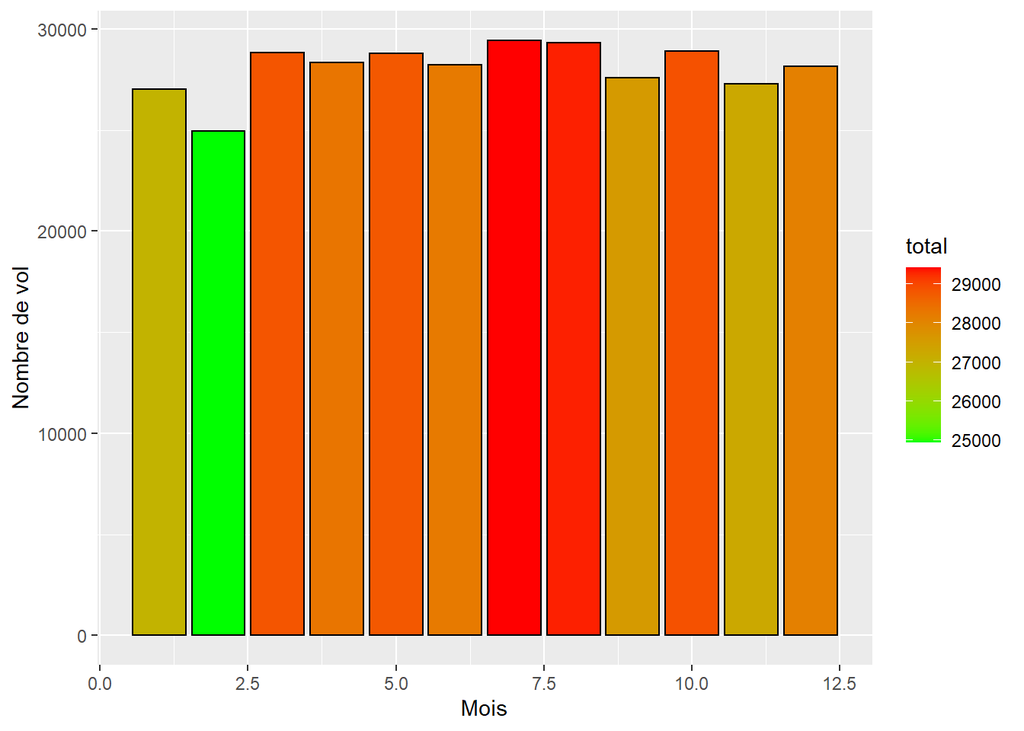

```r
Le_mois_le_plus_overbooké %>% ggplot(aes(x = month, y = total, fill = total)) +
                              geom_bar(stat = "identity", color = "black") +
                              scale_fill_gradient(low = "green", high = "red") +
                              xlab("Mois") +
                              ylab("Nombre de vol")
```

### Quelle est la plus grande distance pour chaque transporteur (Carrier)?

```r
Plus_grande_distance_par_transporteur <- flights_RDS_db %>% select(distance,carrier) %>%
                                                       group_by(carrier) %>%
                                                       summarise(plus_longue_distance = max(distance))

Plus_grande_distance_par_transporteur
```

```
## # Source:   lazy query [?? x 2]
## # Database: mysql 8.0.17
## #   [root@mysql2.c27mabdidald.eu-west-3.rds.amazonaws.com:/nycflights]
##    carrier plus_longue_distance
##    <chr>                  <dbl>
##  1 UA                      4963
##  2 AA                      2586
##  3 B6                      2586
##  4 DL                      2586
##  5 EV                      1389
##  6 MQ                      1147
##  7 US                      2153
##  8 WN                      2133
##  9 VX                      2586
## 10 FL                       762
## # ... with more rows
```

**Graphiquement**

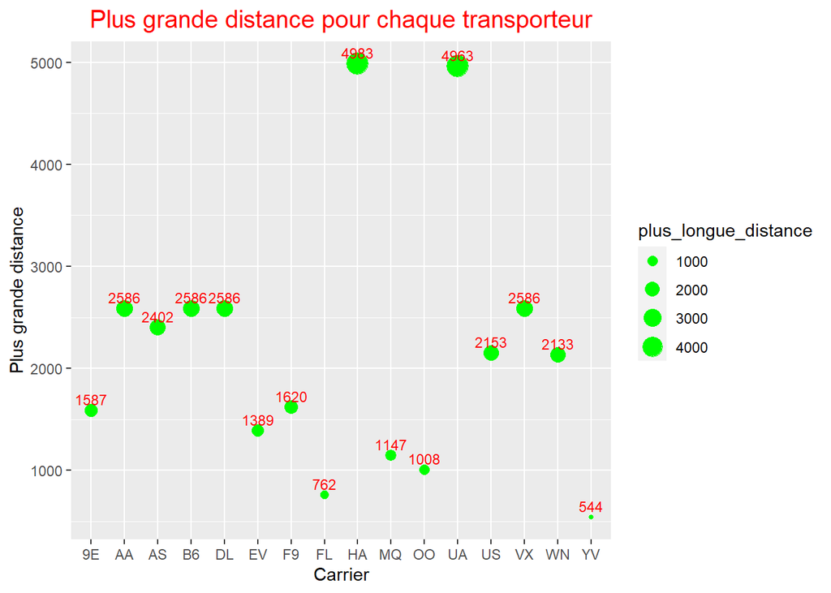

```r
Plus_grande_distance_par_transporteur %>% ggplot(aes(x = carrier, y = plus_longue_distance)) +
                                          geom_point(aes(size = plus_longue_distance), color = "green") +
                                          geom_text(aes(label = plus_longue_distance, hjust = 0.5, vjust = -0.5), size = 3, color = 'red') +
                                          theme(plot.title = element_text(size = 15, hjust = 0.5, color = "red")) +
                                          ggtitle("Plus grande distance pour chaque transporteur") +
                                          xlab("Carrier") +
                                          ylab("Plus grande distance")
```

### Quelle sont les 5 itinéraires de vol les plus courant?

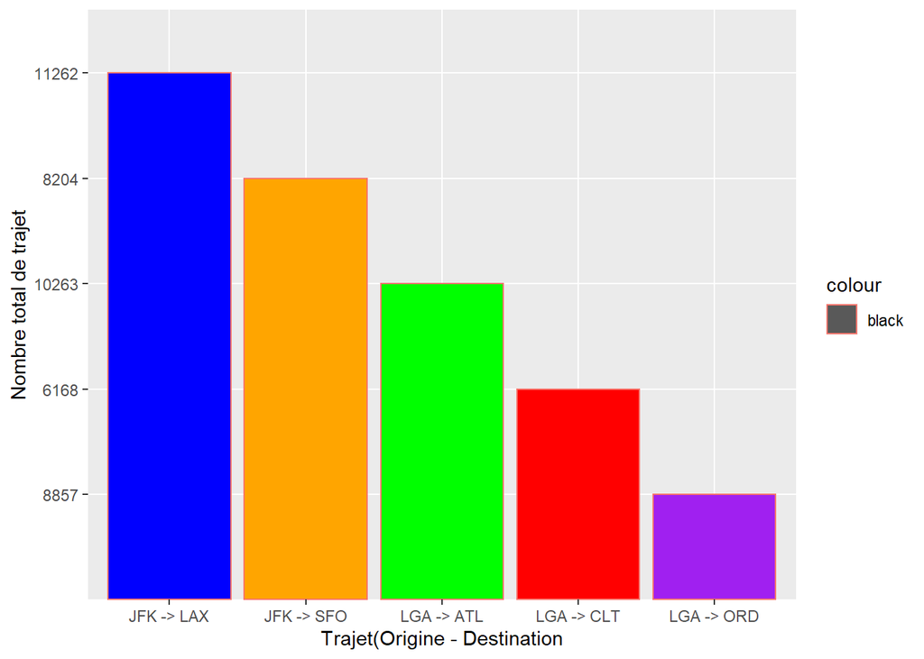

```r
# Requête
les_5_itineraires_les_plus_courant <- flights_RDS_db %>% group_by(origin,dest) %>%
                                                         summarise(total = n()) %>%
                                                         arrange(desc(total)) %>%
                                                         head(5)

# Conversion en Dataframe
les_5_itineraires_les_plus_courant = data.frame(les_5_itineraires_les_plus_courant)

# Concatenons les 2 colonnes + Graphique
Origin_destination <- paste0(les_5_itineraires_les_plus_courant$origin, " -> ", les_5_itineraires_les_plus_courant$dest)
les_5_itineraires_les_plus_courant <- les_5_itineraires_les_plus_courant %>%
                                      mutate(Origin_destination) %>%
                                      mutate(total = factor(total,levels = total[order(Origin_destination,decreasing = TRUE)])) %>%
                                      arrange(desc(total)) %>% ggplot(aes(Origin_destination, total, fill = total, color = "black")) +
                                      geom_bar(stat = "identity", fill = c("blue","orange","green","red","purple")) +
                                      xlab("Trajet(Origine - Destination") +
                                      ylab("Nombre total de trajet")

les_5_itineraires_les_plus_courant
```

### Le transporteur avec le retard de départ le plus élevé a-t-il également le retard d’arrivée le plus élevé?

**1) Le transporteur avec le retard de départ le plus élevé**

```r
Le_transporteur_avec_le_plus_grand_retard_au_depart <- flights_RDS_db %>% group_by(carrier) %>%
                                                                          summarize(plus_grand_retard_depart = max(dep_delay)) %>%
                                                                          arrange(desc(plus_grand_retard_depart)) %>%
                                                                          head(1)
Le_transporteur_avec_le_plus_grand_retard_au_depart
```

```
## # Source:     lazy query [?? x 2]
## # Database:   mysql 8.0.17
## #   [root@mysql2.c27mabdidald.eu-west-3.rds.amazonaws.com:/nycflights]
## # Ordered by: desc(plus_grand_retard_depart)
##   carrier plus_grand_retard_depart
##   <chr>                      <int>
## 1 HA                          1301
```

**2) Le transporteur avec le retard à l’arriver le plus élevé**

```r
Le_transporteur_avec_le_plus_grand_retard_arrive <- flights_RDS_db %>% group_by(carrier) %>%
                                                                       summarize(plus_grand_retard_arrive = max(arr_delay)) %>%
                                                                       arrange(desc(plus_grand_retard_arrive)) %>%
                                                                       head(1)
Le_transporteur_avec_le_plus_grand_retard_arrive
```

```
## # Source:     lazy query [?? x 2]
## # Database:   mysql 8.0.17
## #   [root@mysql2.c27mabdidald.eu-west-3.rds.amazonaws.com:/nycflights]
## # Ordered by: desc(plus_grand_retard_arrive)
##   carrier plus_grand_retard_arrive
##   <chr>                      <int>
## 1 HA                          1272
```

**Conclusion :** *Le transporteur avec le retard de départ le plus élevé est également avec le retard d’arrivé le plus élevé*

### L’unique destination par mois est-il le même tous les mois?

**1) L’unique destination de Janvier**

```r
unique_destination_par_moisr <- flights_RDS_db %>% select(dest,month) %>%
                                                   filter(month == 1) %>%
                                                   group_by(dest) %>%
                                                   summarise(count = n()) %>%
                                                   arrange(count) %>%
                                                   head(1)
unique_destination_par_moisr
```

```
## # Source:     lazy query [?? x 2]
## # Database:   mysql 8.0.17
## #   [root@mysql2.c27mabdidald.eu-west-3.rds.amazonaws.com:/nycflights]
## # Ordered by: count
##   dest  count
##   <chr> <dbl>
## 1 EYW       1
```

**2) L’unique destination de Juin**

```r
unique_destination_par_moisr <- flights_RDS_db %>% select(dest,month) %>%
                                                   filter(month == 6) %>%
                                                   group_by(dest) %>%
                                                   summarise(count = n()) %>%
                                                   arrange(count) %>%
                                                   head(1)
unique_destination_par_moisr
```

```
## # Source:     lazy query [?? x 2]
## # Database:   mysql 8.0.17
## #   [root@mysql2.c27mabdidald.eu-west-3.rds.amazonaws.com:/nycflights]
## # Ordered by: count
##   dest  count
##   <chr> <dbl>
## 1 MYR       1
```

**Conclusion :** *rien qu’en regardant le mois de janvier et de juin on peut en déduire que l’unique destination par mois n’est pas le même*